# ANÁLISIS DE COVARIANZA (COVARIANCE ANALYSIS)

JOSÉ M. GÓMEZ

22/11/2021

# ASPECTOS TEÓRICOS GENERALES

Un bloque es una variable categórica que explica la variación en la variable de respuesta que no es causada por los factores. Aunque cada medición debe realizarse bajo condiciones experimentales consistentes (aparte de los factores que se modifican como parte del experimento), esto no siempre es posible. Debe utilizarse bloques en los experimentos diseñados y en el análisis para minimizar el sesgo y la varianza del error debido a factores perturbadores.

Por ejemplo, se desea evaluar la calidad de una nueva imprenta. Sin embargo, la preparación de la prensa toma varias horas y solo puede hacerse cuatro veces al día. Como el diseño del experimento requiere por lo menos ocho corridas, se necesitan al menos dos días para probar la prensa. Se deben explicar las diferencias en las condiciones entre un día y otro usando **día** como una variable de bloque. Para distinguir entre cualquier efecto de bloque (diferencias incidentales entre los días) y los efectos causados por los factores experimentales (temperatura, humedad y operador de la prensa), debe incluir el bloque (día) en el experimento diseñado. Debe aleatorizarse el orden de las corridas dentro de los bloques (véase https://support.minitab.com/es-mx/minitab/18/help-and-how-to/modeling-statistics/doe/supporting-topics/basics/what-is-a-block/).

El análisis de variancia de un factor en presencia de bloques divide la variabilidad total de la respuesta (Suma de Cuadrados Total) en tres fuentes de variación:

1. Variación entre los promedios del factor (que se calcula como un cuadrado medio de tratamientos).
2. Variación entre los promedios de los bloques (que se calcula como un cuadrado medio de tratamientos).
3. Variación dentro de los tratamientos eliminando el efecto del bloque (CME). El Cuadrado Medio de Error o CME no es una ponderación directa de las varianzas por tratamiento, ya que primero debe eliminarse el efecto del bloque en la Suma de Cuadrados. El CME es una medida de la variabilidad dentro de los tratamientos una vez eliminado el efecto del bloque.

# CASO DE APLICACIÓN: EFECTO DE LA POSICIÓN DE SALIDA Y TIPO DE CALENTAMIENTO EN EL RECORRIDO DE 100 METROS PLANOS

## 1. Planteamiento General del Problema de Investigación

Se hizo un estudio cuyo objetivo era examinar el efecto que tiene la posición de salida y el tipo de calentamiento en el tiempo de recorrido de 100 metros planos. Se trabajó con la población entre 17 a 24 años en la sede Rodrigo Facio de la Universidad Costa Rica.

Se usaron tres tipos de calentamiento: (A) solo estirando, (B) calentamiento normal para hacer ejercicio regular y (C) calentamiento para correr. Además se usaron dos tipos de salida: (+) salida baja con 4 apoyos y (-) salida normal de pie.

Para tomar en cuenta la variabilidad que introduce el hecho de que hay unos estudiantes más grandes que otros y que además tienen pesos diferentes, se tómo el peso y la estatura para calcular el índice de masa corporal de cada uno de ellos, el cual se calcula dividiendo el peso entre la estatura al cuadrado ($IMC=P/E^2$).

La variable de respuesta es el tiempo al recorrer 100 metros planos (en segundos). Los investigadores consideran que una diferencia de 2 segundos entre dos promedios es bastante importante.

```r
load("100metros.Rdata")
str(base)
```

```
## 'data.frame':    66 obs. of  6 variables:
##  $ estatura: int  154 158 151 168 164 161 180 174 174 168 ...
##  $ peso    : num  60.9 55.3 53.6 53.8 53.3 59.6 61.5 80.4 72.4 51.3 ...
##  $ tiempo  : num  12.05 6.81 12.08 7.89 10.38 ...
##  $ calent  : Factor w/ 3 levels "A","B","C": 1 1 1 1 1 1 1 1 1 1 ...
##  $ salida  : Factor w/ 2 levels "-","+": 2 2 2 2 1 1 1 1 1 1 ...
##  $ imc     : num  0.00257 0.00222 0.00235 0.00191 0.00198 ...
```

## 2. Estructura General del Experimento

### 2.1. Factores, Tipos de Factores, Niveles y Cantidad de Niveles por Factor

A partir del peso y estatura de contenidos en la base de datos antes cargada, debe crearse la variable `imc`.

```r
base$imc=base$peso/base$estatura^2
attach(base)
```

Como se verifica, existen 6 tratamientos en el diseño con dos factores de diseño: tipo de calentamiento (3 niveles) y tipo de salida (2 niveles).

### 2.2. Cantidad de Observaciones por Tratamiento

```r
table(calent,salida)
```

```
##       salida
## calent  -  +
##      A 11 11
##      B 11 11
##      C 11 11
```

Se dispone de 11 observaciones por tratamiento.

## 3. Análisis Descriptivo de la Varianza de la Respuesta

```r
v=tapply(tiempo,list(calent,salida),var)
# Varianza de la Respuesta dentro de cada tratamiento
round(v,2)
```

```
##       -     +
## A  6.29 13.56
## B 13.63 10.74
## C  8.45  9.81
```

```r
# Varianza de la Respuesta Asumiendo Homocedasticidad
round(mean(v),2)
```

```
## [1] 10.41
```

Para visualizar la variabilidad dentro de cada tratamiento, es recomendable construir un gráfico del tiempo por tratamiento incluyendo ambos factores de diseño.

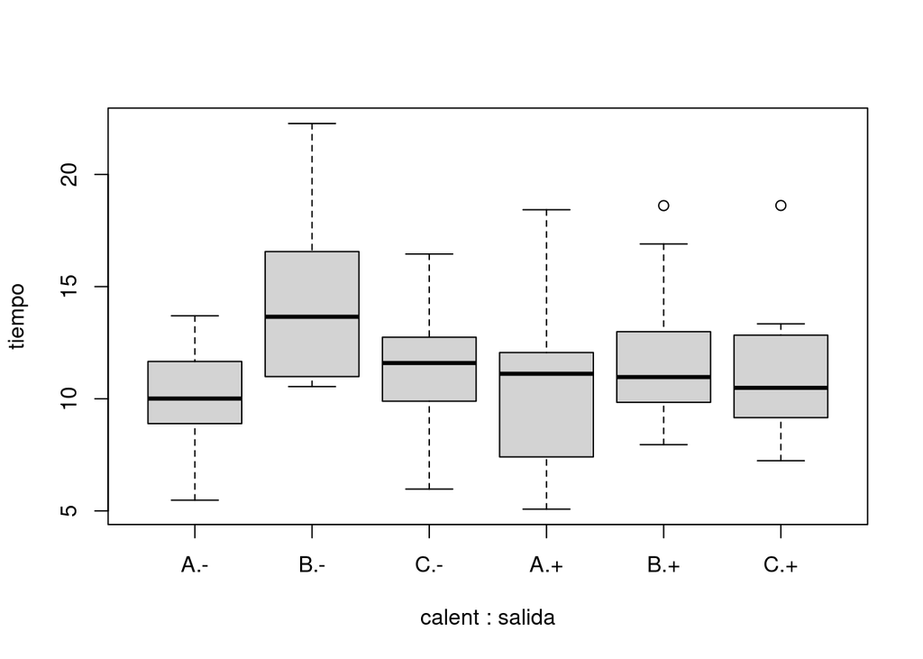

```r
boxplot(tiempo~calent+salida)
```

Ahora se tratará de visualizar la variabilidad de la respuesta tomando en cuenta la covariable. En este caso se tiene una covariable (imc) que se incluye porque se sabe que el tiempo está asociado linealmente al índice de masa corporal como se verá con el cálculo de las correlaciones. Para ello, debe obtenerse primero la correlación entre la respuesta y la covariable.

```r
cor(tiempo,imc)
```

```
## [1] 0.7688473
```

Puede obtenerse también un coeficiente de correlación entre imc y tiempo de recorrido de 100 metros planos dentro de cada uno de los tratamientos (combinaciones de tipos de calentamientos y tipos de salidas). Puede usarse la función `summarise` junto con `group_by` de la librería `dplyr` tal como se presenta a continuación: `summarise(group_by(base,A,B),cor(X,Y))`, donde A y B son los factores que definen los grupos.

```r
library(dplyr)
summarise(group_by(base,calent,salida),cor(imc,tiempo))
```

```
## # A tibble: 6 × 3
## # Groups:   calent [3]
##   calent salida `cor(imc, tiempo)`
##   <fct>  <fct>               <dbl>
## 1 A      -                   0.860
## 2 A      +                   0.784
## 3 B      -                   0.876
## 4 B      +                   0.917
## 5 C      -                   0.608
## 6 C      +                   0.760
```

Adicionalmente, es importante verificar que la relación que existe entre la respuesta y la covariable es lineal dentro de cada tratamiento. Para esto, es recomendable elaborar un gráfico usando la sintaxis `scatterplot` de la librería `car` de la siguiente forma: `scatterplot(y~x+A+B)`. Dado cada par de líneas de un mismo color, la línea recta indica una relación lineal perfecta, mientras que la línea curva sigue los datos. Si ambas son similares geométricamente es porque sí existe una fuerte relación lineal entre la covariable y la respuesta.

```r
library(car)
```

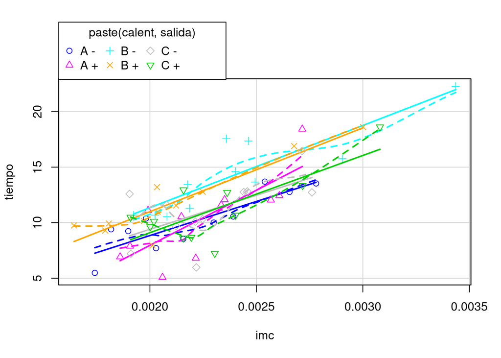

```r
scatterplot(tiempo~imc+paste(calent,salida))
```

```r
#scatterplot(tiempo~imc+calent+salida)
```

Puede elaborarse un gráfico de puntos del tiempo contra el imc agregando una línea de regresión para cada tipo de calentamiento usando `xyplot(Y~X|A,type=c("r","p"))`.

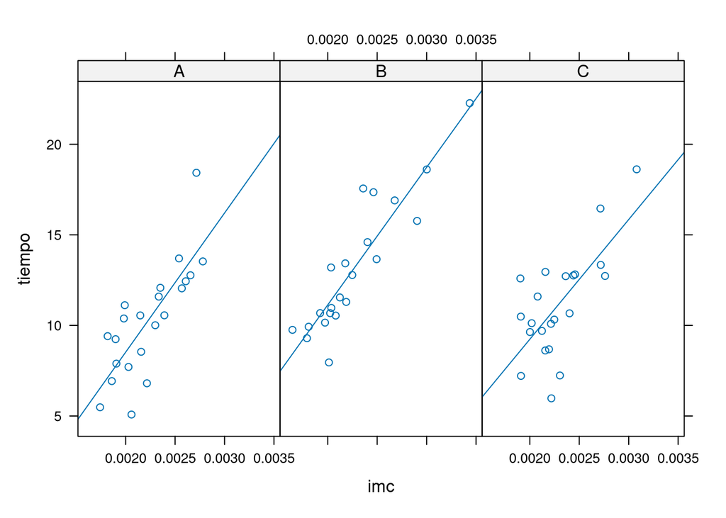

```r
library(lattice)
xyplot(tiempo~imc|calent,type=c("r","p"))
```

Complementariamente, puede elaborarse un gráfico de puntos del tiempo contra el imc agregando una línea de regresión para cada tratamiento. Pueden introducirse los dos factores dentro de la función `xyplot` de la siguiente forma: `xyplot(Y~X|A+B,type=c("r","p"))`.

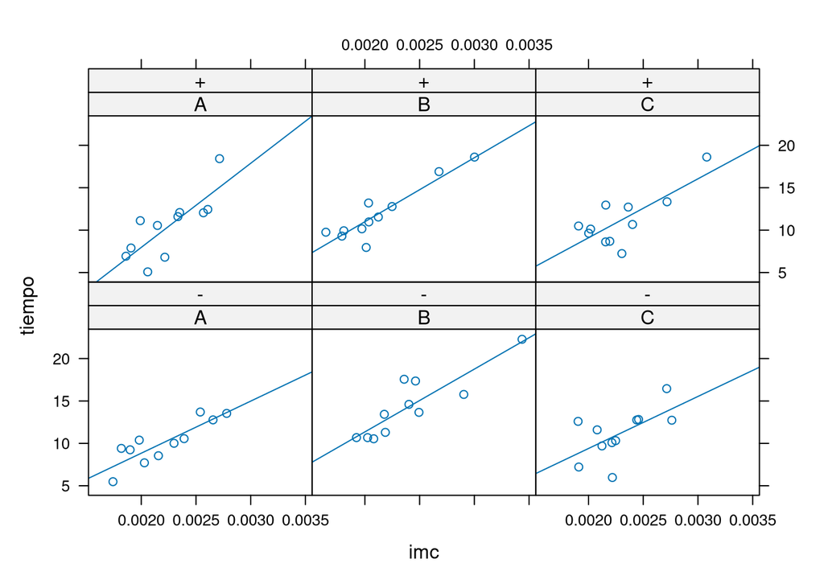

```r
xyplot(tiempo~imc|calent+salida,type=c("r","p"),
auto.key = T)
```

## 4. Modelo de Ajuste con Interacción Entre Factores de Diseño

Para tomar en cuenta la variabilidad que está induciendo el imc, se debe hacer un modelo con los factores y la covariable. Puede incluirse la interacción entre los dos factores de diseño y luego obtener los residuales del modelo.

```r
mod1=lm(tiempo~calent*salida+imc)
r1=mod1$res
head(r1)
```

```
##           1           2           3           4           5           6
## -0.72065485 -3.38658533  0.89519029 -0.04449431  1.91562494 -0.77570412
```

Cada uno de los residuales representa la distancia del valor observado a la recta correspondiente en cada tratamiento (lo que implica que no existe una única recta) o, en otras palabras, es la distancia del valor observado a la recta del tratamiento al que pertenece, el cual es el promedio estimado para ese tratamiento.

Es necesario estimar el Cuadrado Medio Residual del modelo a partir de los residuales.

```r
CMRes=sum(r1^2)/59 #son 66 observaciones y 7 efectos a estimar, por lo que los grados de libertad son 59
CMRes
```

```
## [1] 3.747529
```

Es recomendable comparar el cuadrado medio residual obtenido en este modelo con la estimación de la varianza por tratamiento de la respuesta asumiendo homocedasticidad que se obtuvo anteriormente.

```r
CMRes; mean(v)
```

```
## [1] 3.747529
```

```
## [1] 10.4131
```

En el modelo se obtiene varianza residual de 3.75, mientras que la varianza inicial fue de 10.41. Se concluye que al incluir el imc se reduce enormemente la variabilidad residual.

## 5. Modelo de Ajuste sin Índice de Masa Corporal

Para estudiar el efecto de los factores de diseño es importante tomar en cuenta que el imc introduce mucho ruido (porque genera una variabilidad no-controlable en cuanto el imc de los corredores existe con independencia de las facultades de control experimental del investigador).

Así, es necesario proceder a elaborar un modelo con los dos factores de diseño sin la inclusión del imc. Pueden plantearse dos versiones de tal modelo, cada una con un orden de los factores y tras ello generar las tablas ANOVAS de los modelos para verificar si la alteración del orden de los factores en la especificación del modelo (en ambos casos sin imc) genera alteraciones estadísticas en el proceso de estimación.

```r
mod2a=lm(tiempo~calent*salida)
mod2b=lm(tiempo~salida*calent)
anova(mod2a)
```

```
## Analysis of Variance Table
##
## Response: tiempo
##               Df Sum Sq Mean Sq F value  Pr(>F)
## calent         2  93.77  46.884  4.5024 0.01507 *
## salida         1   7.53   7.527  0.7229 0.39859
## calent:salida  2  25.62  12.811  1.2303 0.29947
## Residuals     60 624.79  10.413
## ---
## Signif. codes:  0 '***' 0.001 '**' 0.01 '*' 0.05 '.' 0.1 ' ' 1
```

```r
anova(mod2b)
```

```
## Analysis of Variance Table
##
## Response: tiempo
##               Df Sum Sq Mean Sq F value  Pr(>F)
## salida         1   7.53   7.527  0.7229 0.39859
## calent         2  93.77  46.884  4.5024 0.01507 *
## salida:calent  2  25.62  12.811  1.2303 0.29947
## Residuals     60 624.79  10.413
## ---
## Signif. codes:  0 '***' 0.001 '**' 0.01 '*' 0.05 '.' 0.1 ' ' 1
```

Se observa que el resultado del anova es el mismo con independencia del orden de los factores.

## 6. Prueba de Hipótesis Sobre Igualdad de Medias

Es necesario hacer la prueba de hipótesis correspondiente para determinar si alguno de los tipos de calentamiento produce una media de tiempo diferente observando las probabilidades asociadas a los efectos sin interacción (por ello, debe indicarse en la sintaxis un modelo sin interacción).

```r
mod3=lm(tiempo~calent+salida)
anova(mod3)
```

```
## Analysis of Variance Table
##
## Response: tiempo
##           Df Sum Sq Mean Sq F value  Pr(>F)
## calent     2  93.77  46.884  4.4692 0.01537 *
## salida     1   7.53   7.527  0.7175 0.40022
## Residuals 62 650.41  10.490
## ---
## Signif. codes:  0 '***' 0.001 '**' 0.01 '*' 0.05 '.' 0.1 ' ' 1
```

Se rechaza la hipótesis de igualdad de medias, por lo que hay evidencia de que alguno de los tipos de calentamiento produce una media menor que las otras. La probabilidad asociada es 0.015.

## 7. Modelo de Ajuste con Covariable imc y Sin Interacción

Con la finalidad de determinar la significancia estadística de los factores y la covariable imc, el primer paso necesario es construir un modelo que tome en cuenta la covariable imc sin tomar en cuenta la interacción entre los factores de diseño, con la finalidad de utilizar este escenario para evaluar la significancia de dicha covariable. Es recomendable realizar esto colocando primero los factores, luego la covariable y luego otro modelo en donde primero entre la covariable y luego los factores (con lo que se obtienen dos modelos), con la finalidad de determinar si el orden de ingreso en la ecuación de regresión afecta las estimaciones inferenciales realizadas o no.

```r
mod4a=lm(tiempo~calent+salida+imc)
mod4b=lm(tiempo~imc+calent+salida)
anova(mod4a)
```

```
## Analysis of Variance Table
##
## Response: tiempo
##           Df Sum Sq Mean Sq  F value    Pr(>F)
## calent     2  93.77   46.88  12.9096 2.112e-05 ***
## salida     1   7.53    7.53   2.0726    0.1551
## imc        1 428.87  428.87 118.0888 6.736e-16 ***
## Residuals 61 221.54    3.63
## ---
## Signif. codes:  0 '***' 0.001 '**' 0.01 '*' 0.05 '.' 0.1 ' ' 1
```

```r
anova(mod4b)
```

```
## Analysis of Variance Table
##
## Response: tiempo
##           Df Sum Sq Mean Sq  F value    Pr(>F)
## imc        1 444.35  444.35 122.3515 3.268e-16 ***
## calent     2  85.50   42.75  11.7705 4.753e-05 ***
## salida     1   0.32    0.32   0.0878     0.768
## Residuals 61 221.54    3.63
## ---
## Signif. codes:  0 '***' 0.001 '**' 0.01 '*' 0.05 '.' 0.1 ' ' 1
```

Los resultados no se mantienen al intercambiar el orden. Esto sucede en un modelo de regresión ya que el análisis de varianza (ANOVA) va tomando lo que explica una variable después de que han entrado otras variables, entonces el orden en que entra es importante.

Dado que el ANOVA en este caso se ve afectado por el orden en que se introducen los factores, siempre se debe colocar como último miembro de la ecuación el factor que se está poniendo a prueba (del que se está midiendo su aporte marginal), por lo que se obtiene `mod4=lm(tiempo~calent+salida+imc)`, es decir, del que se desea determinar su el aporte marginal (imc en este caso).

Conocido lo anterior y siendo también de interés conocer la significancia estadística del factor **calentamiento**, el siguiente paso es (antes de realizar la prueba de hipótesis correspondiente a la significancia de **imc**) configurar y ejecutar dos modelos: 1) con la respuesta, con los dos factores de diseño y la covariable, 2) sólo con respuesta y la covariable, con la finalidad de evaluar el ajuste considerando el tipo de calentamiento versus el escenario en el que no se considera. Se representa como $\Omega$ al modelo que incluye al factor calentamiento, mientras que como $\omega$ al modelo que lo excluye.

```r
mod4=lm(tiempo~calent+salida+imc)
mod5=lm(tiempo~salida+imc)
```

Debe encontrarse la SCRes de ambos modelos, representadas como $SCRes_\Omega$ y $SCRes_\omega$. A partir de ellas, puede obtenerse la Suma de Cuadrados de Regresión Marginal como $SCRegMar=SCRes_\omega-SCRes_\Omega$, la cual representa la parte de la variabilidad de la respuesta que es explicada por calentamiento cuando entra después de las otras dos variables.

```r
SCRes1=anova(mod4)[4,2]
SCRes2=anova(mod5)[3,2]
SCRegMar=SCRes2-SCRes1
```

## 8. Prueba F

Debe realizarse una prueba F para determinar la significancia estadística del aporte marginal de los diferentes tipos de calentamiento, con la finalidad de verificar si su aporte es realmente el mismo o existe diferencia entre ellos.

$$F=\frac{\frac{SCRegMar}{diff.gl}}{CMRes_\Omega}$$

Donde diff.gl es la diferencia en los grados de libertad residuales entre los dos modelos de comparación.

Para realizar la prueba de hipótesis requerida, es necesario antes estimar el valor F asociado a dicha prueba.

```r
CMRes=anova(mod4)[4,3]
f=(SCRegMar/2)/CMRes
f
```

```
## [1] 11.77287
```

A continuación, debe realizarse la prueba de la hipótesis obteniendo la probabilidad asociada a este valor de F en una distribución que tiene 66-5 (puesto que son cinco coeficientes ya que no se consideran los efectos con interacción) grados de libertad.

```r
pf(f,2,61,lower.tail = F)
```

```
## [1] 4.745278e-05
```

La hipótesis nula sostiene que ambos modelos tienen la misma capacidad explicativa a nivel estadístico, lo cual es equivalente a decir que los coeficientes de los diferentes tipos de calentamiento son iguales entre sí e iguales a cero. Esto significa que las medias del tiempo son iguales para todos los tipos de calentamiento. A causa del bajo valor de probabilidad F, se rechaza la hipótesis nula de igualdad de medias para los diferentes tipos de calentamiento.

El procedimiento de verificación de significancia de **imc** puede automatizarse y, a causa de la robustez interna del paquete a llamar, mejorar la precisión enormemente, garantizando así que en realidad se escoja el modelo estadísticamente más robusto (esto es aplicable a cualquier verificación de la misma índole). Esto puede realizarse mediante la sintaxis `drop1`, a la cual hay que agregar el agrumento `test="F"`, que permite comparar dos modelos, uno con la variable de interés a probar y otro sin ella.

```r
drop1(mod4a, test="F")
```

```
## Single term deletions
##
## Model:
## tiempo ~ calent + salida + imc
##        Df Sum of Sq    RSS     AIC  F value    Pr(>F)
## <none>              221.54  89.922
## calent  2     85.51 307.05 107.466  11.7729 4.745e-05 ***
## salida  1      0.32 221.86  88.017   0.0878     0.768
## imc     1    428.87 650.41 159.004 118.0888 6.736e-16 ***
## ---
## Signif. codes:  0 '***' 0.001 '**' 0.01 '*' 0.05 '.' 0.1 ' ' 1
```

```r
drop1(mod4b, test="F")
```

```
## Single term deletions
##
## Model:
## tiempo ~ imc + calent + salida
##        Df Sum of Sq    RSS     AIC  F value    Pr(>F)
## <none>              221.54  89.922
## imc     1    428.87 650.41 159.004 118.0888 6.736e-16 ***
## calent  2     85.51 307.05 107.466  11.7729 4.745e-05 ***
## salida  1      0.32 221.86  88.017   0.0878     0.768
## ---
## Signif. codes:  0 '***' 0.001 '**' 0.01 '*' 0.05 '.' 0.1 ' ' 1
```

En cualquier orden que se pogan los factores en el modelo se obtiene la misma probabilidad asociada a la prueba que interesa.

- Observe la probabilidad asociada al factor de calentamiento y compárela con la que se había obtenido en el anova que no consideraba el imc.

**Ahora la probabilidad asociada es de 0.00005 que es mucho menor que la obtenida anteriormente (0.015).**

5. Considere la interacción entre los dos factores de diseño. Esto es lo primero que debió probarse aunque aquí se esté analizando hasta ahora.
- Tome el modelo que contiene la interacción entre esos dos factores y además contiene la covariable. Usando el `drop1` puede verificar la hipótesis de no interacción.

```r
mod1
```

```
##
## Call:
## lm(formula = tiempo ~ calent * salida + imc)
##
## Coefficients:
##     (Intercept)          calentB          calentC          salida+
##        -6.00047          2.79516          0.47484          0.01995
##             imc  calentB:salida+  calentC:salida+
##      7300.66343         -0.39066         -0.09953
```

```r
drop1(mod1,test="F")
```

```
## Single term deletions
##
## Model:
## tiempo ~ calent * salida + imc
##               Df Sum of Sq    RSS     AIC  F value   Pr(>F)
## <none>                     221.10  93.793
## imc            1    403.68 624.79 160.352 107.7194 6.27e-15 ***
## calent:salida  2      0.43 221.54  89.922   0.0578   0.9439
## ---
## Signif. codes:  0 '***' 0.001 '**' 0.01 '*' 0.05 '.' 0.1 ' ' 1
```

**La probabilidad asociada es muy alta por lo que se asume que no hay interacción entre calentamiento y salida. Esto lleva a suponer que el efecto que tiene el tipo de calentamiento sobre el tiempo promedio es independiente del tipo de salida. Es correcto el análisis que se hizo de verificar el efecto del calentamiento en general.**

6. En este tipo de análisis puede resultar más conveniente usar el modelo de tratamiento referencia. En cualquiera de los dos modelos el intercepto no representa la media general. La dirección de las comparaciones se hace basada en los coeficientes del factor que se analiza, recordando que el tratamiento referencia tiene un coeficiente igual a cero.
- Escriba el modelo resultante.

$$\mu_{ij},x =
\beta_0+\alpha_i+\beta_j+\gamma_X$$

- Investigue con cuál tipo de calentamiento se puede esperar el menor tiempo promedio.  
  **Primero se obtienen los coeficientes y se observa que la referencia es el tipo A, además el coeficiente más alto es para B y luego C. Entonces se comparan B-C, B-A y C-A.**

```r
tapply(tiempo,calent,mean)
```

```
##        A        B        C
## 10.28539 13.13294 11.15068
```

```r
b=mod4b$coef
b
```

```
##  (Intercept)          imc      calentB      calentC      salida+
##   -6.0325098 7350.8600225    2.5981267    0.4220462   -0.1397913
```

```r
#Se hace el planteamiento de los dos contrastes restando el contraste que estima a cada uno por aparte.
#cBC(0,0,1,0,0)-(0,0,0,1,0)=c(0,0,1,-1,0)
cBC=c(0,0,1,-1,0)

#cBA(0,0,1,0,0)-(0,0,0,0,0)=c(0,0,1,0,0)
cBA=c(0,0,1,0,0)
cCA=c(0,0,0,1,0)
cont=cbind(cBC,cBA,cCA)
L=t(cont)%*%b
L
```

```
##          [,1]
## cBC 2.1760805
## cBA 2.5981267
## cCA 0.4220462
```

```r
ee=sqrt(diag(t(cont)%*%vcov(mod4b)%*%cont))
qt=L/ee
p=pt(qt,61,lower.tail = F)
round(p,2)
```

```
##     [,1]
## cBC 0.00
## cBA 0.00
## cCA 0.23
```

```r
p<0.05/3
```

```
##      [,1]
## cBC  TRUE
## cBA  TRUE
## cCA FALSE
```

**Se encuentran diferencias entre B-C y B-A. Ahora se construye un límite inferior para esas diferencias.**

```r
qt=qt(1-0.05/2,61)
lim=L[1:2]-qt*ee[1:2]
round(lim,2)
```

```
##  cBC  cBA
## 1.03 1.45
```

### Asfalto

Se hizo un estudio cuyo objetivo era investigar si al implementar antioxidantes como aditivos para el mortero asfáltico (agregado + asfalto) retardan el proceso de oxidación. Se utilizan dos variables como indicadores de este proceso: el módulo complejo (MegaPascales) y el ángulo de fase (grados).

En el estudio se quieren comparar 2 antioxidantes (ácido ascórbico y orujo) donde cada uno de ellos se utiliza en tres diferentes concentraciones (1, 3 y 5%).

Además de los factores de diseño se sabe que los resultados de las variables críticas se miden a temperaturas y frecuencias determinadas las cuales van a impactar estos resultados. Estas temperaturas y frecuencias también se obtienen para ciertos períodos de envejecimiento determinados (4, 8 y 16 años).

Adicionalmente se tienen dos fuentes de donde proviene el agregado o piedra fina (Barranca y Guápiles). Si bien el conocer el efecto de la fuente de agregado no es el objetivo primordial del estudio, podría darse que la fuente introduzca variabilidad en los resultados.

Puesto que las dos variables respuesta están altamente correlacionadas, el investigador decidió concentrar su análisis en el módulo. Él considera que una diferencia de 10 MegaPascales entre dos promedios es bastante considerable. El antioxidante que tenga un módulo promedio menor se considera más apropiado.

### Ejercicios

1. Cargue el archivo `asfalto.Rdata`. Para iniciar se van a considerar solo los datos para una concentración de 5% que corresponde al nivel “alto” en la variable `conc`. Cambie los niveles de agregado a las iniciales de cada sitio para que sea más fácil de leer en los análisis. Haga una nueva base donde se filtren sólo los los datos que se requieren.

```r
load("asfalto.Rdata")
str(base)
```

```
## 'data.frame':    1080 obs. of  8 variables:
##  $ env   : Factor w/ 3 levels "4","8","16": 1 1 1 1 1 1 1 1 1 1 ...
##  $ antiox: Factor w/ 2 levels "ASC","OR": 1 1 1 1 1 1 1 1 1 1 ...
##  $ agreg : Factor w/ 2 levels "Barranca","Guapiles": 1 1 1 1 1 1 1 1 1 1 ...
##  $ conc  : Factor w/ 3 levels "bajo","medio",..: 1 1 1 1 1 1 1 1 1 1 ...
##  $ frec  : num  0.1 0.5 1 5 10 25 0.1 0.5 1 5 ...
##  $ temp  : num  -10 -10 -10 -10 -10 -10 4 4 4 4 ...
##  $ mod   : num  83.5 86.4 92.3 97.3 100.4 ...
##  $ ang   : num  7.11 5.58 5.16 4.72 4.54 ...
```

```r
levels(base$agreg)
```

```
## [1] "Barranca" "Guapiles"
```

```r
levels(base$agreg)=c("B","G")
base2=subset(base,conc=="alto")
attach(base2)
```

- ¿Cuáles son los factores de diseño? ¿Cuántos tratamientos tiene este experimento?

**Hay un factor de diseño que es el tipo de antioxidante puesto que la concentración se ha fijado en el nivel alto. Hay 2 tratamientos en el diseño.**

- ¿Cuántas repeticiones hay en cada tratamiento?

```r
table(antiox)
```

```
## antiox
## ASC  OR
## 180 180
```

**Hay 180 observaciones por tratamiento.**

- Puesto que el envejecimiento y el agregado son dos factores que se controlan, se van a incluir en el análisis para reducir el ruido. Al incluir estos dos nuevos factores, ¿cuántas combinaciones tratamiento-factor se obtienen?  
  **Se obtienen 12 combinaciones (2x3x2).**
- ¿Cuántas repeticiones hay en cada combinación?

```r
table(antiox,env,agreg)
```

```
## , , agreg = B
##
##       env
## antiox  4  8 16
##    ASC 30 30 30
##    OR  30 30 30
##
## , , agreg = G
##
##       env
## antiox  4  8 16
##    ASC 30 30 30
##    OR  30 30 30
```

**Hay 30 repeticiones por combinación.**

2. Obtenga la variancia de la respuesta dentro de cada tratamiento. Obtenga una estimación de la variabilidad dentro de cada tratamiento asumiendo homoscedasticidad.

```r
v1=tapply(mod,antiox,var)
round(v1,2)
```

```
##     ASC      OR
## 2785.96 2719.50
```

```r
round(mean(v1),2)
```

```
## [1] 2752.73
```

- Obtenga la variancia de la respuesta dentro de cada combinación tratamiento-factor. Obtenga una estimación de la variabilidad dentro de cada combinación asumiendo homoscedasticidad. Compare esta medida de la variabilidad con la que había obtenido anteriormente.

```r
v2=tapply(mod,list(antiox,env, agreg),var)
round(v2,2)
```

```
## , , B
##
##           4       8      16
## ASC 1285.30 3179.16 2793.84
## OR   975.75 3085.56 2893.70
##
## , , G
##
##           4       8      16
## ASC 2617.08 3635.20 2958.46
## OR  2232.19 3382.78 2769.04
```

```r
round(mean(v2),2)
```

```
## [1] 2650.67
```

**Ahora se obtiene una variancia media de 2650.7 la cual es menor que la que se obtuvo anteriormente de 2752.7, sin embargo no es mucha la disminución que se logra.**

- Para visualizar la variabilidad dentro de cada tratamiento haga primero un gráfico del módulo por tratamiento. Al lado haga un gráfico del módulo por combinación tratamiento-factor. Observe que las etiquetas del eje X son muy largas por lo que no caben, entonces se pueden voltear usando `las=2` en el boxplot.

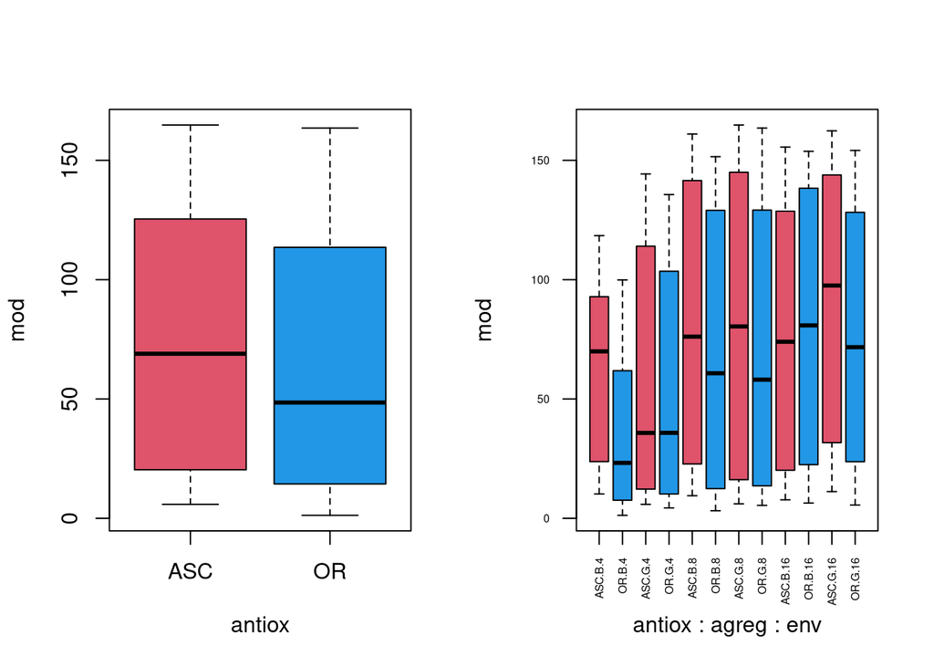

```r
par(mfrow=c(1,2))
boxplot(mod~antiox,col=c(2,4))
boxplot(mod~antiox+agreg+env,col=c(2,4),cex.axis=0.5,las=2)
```

- Discuta si el haber agregado los factores controlados disminuyó la variabilidad de tal forma que sea más evidente si uno de los antioxidantes es mejor que el otro en términos del promedio de módulo.

**En ambos gráficos se nota una variabilidad muy similar dentro de cada tratamiento y es difícil determinar si alguno de los antioxidantes produce un módulo promedio menor que el otro.**

3. Ahora se tratará de visualizar la variabilidad de la respuesta tomando en cuenta una de las covariables. En este caso se tienen dos covariables (temperatura y frecuencia) que se incluyen porque se sabe que el módulo está asociado con la temperatura y con la frecuencia.
- Obtenga la correlación entre la respuesta y cada una de las covariables.

```r
cor(cbind(temp, frec),mod)
```

```
##            [,1]
## temp -0.9036879
## frec  0.1719220
```

- Obtenga estas mismas correlaciones pero dentro de alguno de los tratamientos según el factor de diseño.

```r
summarise(group_by(base2,antiox),cor(temp,mod))
```

```
## # A tibble: 2 × 2
##   antiox `cor(temp, mod)`
##   <fct>             <dbl>
## 1 ASC              -0.923
## 2 OR               -0.893
```

```r
summarise(group_by(base2,antiox),cor(frec,mod))
```

```
## # A tibble: 2 × 2
##   antiox `cor(frec, mod)`
##   <fct>             <dbl>
## 1 ASC               0.177
## 2 OR                0.169
```

**La correlación entre módulo y temperatura es bastante alta tanto en general como dentro de cada nivel de antioxidante, sin embargo, la correlación entre módulo y frecuencia no es tan alta.**

- Haga un grafico de puntos del módulo contra la temperatura agregando una línea de regresión para cada antioxidante. Use la función `xyplot` de la librería `lattice`: `xyplot(Y~X|F,type=c("r","p"))` donde Y es la respuesta, X es la covariable y F es el factor.

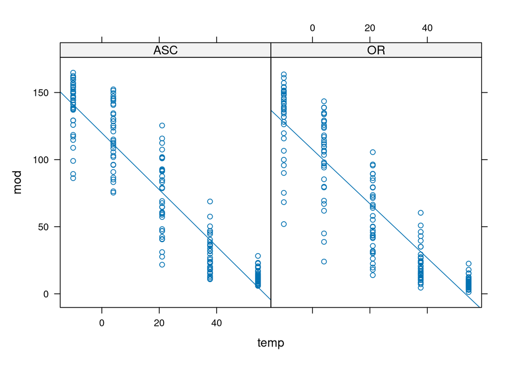

```r
library(lattice)
xyplot(mod~temp|antiox,type=c("r","p"))
```

- Observe la variabilidad que hay alrededor de cada línea. Si hace una relación con un modelo de regresión, ¿a qué concepto corresponde esta variabilidad?

**Esta variabilidad corresponde a la variancia residual en un modelo de regresión y se podría estimar con el Cuadrado Medio Residual.**

- Aunque la temperatura es una variable continua, en este caso se ha medido de una forma muy particular porque se tienen muchos datos en cada una de las 5 temperaturas del estudio. Esto permite que se pueda visualizar la variabilidad que hay alrededor de cada media usando un boxplot. En una sola ventana dividida en tres partes repita los dos boxplot que hizo anteriormente y agregue otro boxplot con el módulo contra la combinación de antioxidante y temperatura.

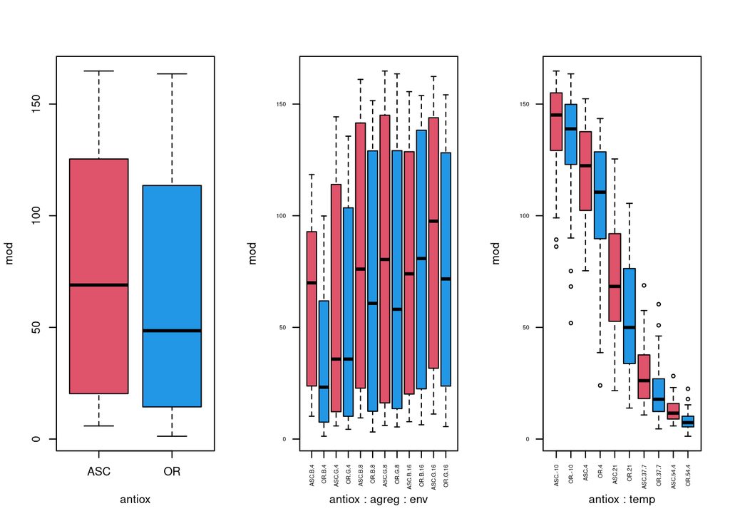

```r
par(mfrow=c(1,3))
boxplot(mod~antiox,col=c(2,4))
boxplot(mod~antiox+agreg+env,col=c(2,4),cex.axis=0.5,las=2)
boxplot(mod~antiox+temp,col=c(2,4),cex.axis=0.5,las=2)
```

```r
par(mfrow=c(1,1)) #Se puede usar para revisar el ultimo gráfico que casi no se ve. Alli se analiza las diferentes temperaturas
```

- Para tomar en cuenta la variabilidad que está induciendo la temperatura, se debe hacer un modelo con el factor y la covariable. También haga un modelo donde sólo se tiene el factor de diseño.

```r
mod1=lm(mod~antiox)
mod2=lm(mod~temp+antiox)
```

- Obtenga el Cuadrado Medio Residual en ambos modelos. Compare los resultados entre sí y compárelos con la estimación de la variancia por tratamiento original.

```r
cmr1=anova(mod1)[2,3]
cmr2=anova(mod2)[3,3]
round(c(cmr1,cmr2,mean(v1)),2)
```

```
## [1] 2752.73  483.91 2752.73
```

**En el modelo donde sólo se incluye el factor de diseño se obtiene variancia residual de 2752.7mientras que en el modelo donde se ha incluido la temperatura la variancia residual se reduce a 483.9. Al incluir la temperatura se reduce la variabilidad residual enormemente. Cuando se consideraron los tratamientos según el factor de diseño se obtuvo una variancia promedio igual a la del modelo que tiene sólo el factor de diseño.**

4. Haga la prueba de hipótesis correspondiente para determinar si alguno de los antioxidantes es mejor en términos de reducir el módulo promedio. Hágalo primero en un análisis de variancia que sólo considera el factor de diseño, luego tome en cuenta la temperatura. Cuando se tienen covariables hay que tener mucho cuidado con el uso de la función `anova` ya que la forma en que se presenta hace un análisis del aporte marginal de las variables. En este caso interesa analizar la variabilidad que explica el antioxidante una vez que se ha eliminado el ruido que introduce la temperatura, por esto, debe introducirse primero la temperatura y luego el antioxidante. **Sin embargo, en este caso la covariable se ha medido de forma discreta y se cuenta con igual cantidad de repeticiones en cada combinación de antioxidante y temperatura, por esta razón el diseño resulta simétrico y se obtiene el mismo resultado en cualquier orden que se introduzcan las variables en la fórmula**. En general es más recomendable usar la función `drop1` indicando `test="F"` para evitar confusiones (esto se puede ver más claramente en otro ejemplo).

```r
anova(mod1)
```

```
## Analysis of Variance Table
##
## Response: mod
##            Df Sum Sq Mean Sq F value  Pr(>F)
## antiox      1   9709  9709.2  3.5271 0.06118 .
## Residuals 358 985477  2752.7
## ---
## Signif. codes:  0 '***' 0.001 '**' 0.01 '*' 0.05 '.' 0.1 ' ' 1
```

```r
anova(mod2)
```

```
## Analysis of Variance Table
##
## Response: mod
##            Df Sum Sq Mean Sq  F value    Pr(>F)
## temp        1 812721  812721 1679.483 < 2.2e-16 ***
## antiox      1   9709    9709   20.064  1.01e-05 ***
## Residuals 357 172756     484
## ---
## Signif. codes:  0 '***' 0.001 '**' 0.01 '*' 0.05 '.' 0.1 ' ' 1
```

```r
drop1(mod1,test="F")
```

```
## Single term deletions
##
## Model:
## mod ~ antiox
##        Df Sum of Sq    RSS    AIC F value  Pr(>F)
## <none>              985477 2853.3
## antiox  1    9709.2 995186 2854.8  3.5271 0.06118 .
## ---
## Signif. codes:  0 '***' 0.001 '**' 0.01 '*' 0.05 '.' 0.1 ' ' 1
```

```r
drop1(mod2,test="F")
```

```
## Single term deletions
##
## Model:
## mod ~ temp + antiox
##        Df Sum of Sq    RSS    AIC  F value    Pr(>F)
## <none>              172756 2228.5
## temp    1    812721 985477 2853.3 1679.483 < 2.2e-16 ***
## antiox  1      9709 182465 2246.2   20.064  1.01e-05 ***
## ---
## Signif. codes:  0 '***' 0.001 '**' 0.01 '*' 0.05 '.' 0.1 ' ' 1
```

- ¿Cuál es el papel de la temperatura en el análisis?

**En este caso el investigador no está interesado en analizar el impacto que tiene la temperatura sobre el módulo promedio, sino que se introduce en el análisis debido a que hay un enorme ruido en la variable respuesta que es debido a la temperatura. Al eliminar ese ruido o variabilidad, las diferencias entre los promedios para los dos antioxidantes se hacen más evidentes.**

5. Ahora vamos a realizar el análisis tomando en cuenta todos los factores incluidos en el estudio. Para esto vemos que hay dos covariables (temperatura y frecuencia), y también se tienen el envejecimiento y el agregado además del factor de diseño antioxidante. Para que las interpretaciones no sean tan complicadas es deseable que no exista interacción entre factor de diseño y las covariables continuas. El modelo inicial debe incluir estas interacciones para probar si el supuesto de no interacción se cumple. Además deben incluirse interacciones entre el factor de diseño y otros factores incluidos en el diseño. En el modelo se usa la siguiente notación: i para antioxidante, j para envejecimiento, k para agregado, $X_1$ para temperatura y $X_2$ para frecuencia. Se usa el término $\alpha^{(1)}_i$ para referirse a la interacción entre antioxidante y temperatura, y $\alpha^{(2)}_i$ para referirse a la interacción entre antioxidante y frecuencia. El modelo completo es el siguiente:

$$\mu_{ijk,X_1,X_2}=\beta_0+\alpha_i+\delta_j+\tau_k+\beta_1
X_1+\beta_2 X_2 +(\alpha \delta)_{ij}+(\alpha
\tau)_{ik}+\alpha^{(1)}_iX_1+\alpha^{(2)}_iX_2$$

- Compare el modelo completo contra otro modelo donde no hay interacciones entre el factor de diseño y las covariables. Debe ajustar el modelo completo y además otro modelo donde no tenga las interacciones que se mencionan. Luego debe comparar los dos modelos con `anova(mod.pequeño,mod.grande)`. Establezca la hipótesis nula que se va a probar y dé una conclusión.

```r
mod3=lm(mod~antiox*env+antiox*agreg+antiox*temp+antiox*frec)
mod4=lm(mod~antiox*env+antiox*agreg+temp+frec)
anova(mod4,mod3)
```

```
## Analysis of Variance Table
##
## Model 1: mod ~ antiox * env + antiox * agreg + temp + frec
## Model 2: mod ~ antiox * env + antiox * agreg + antiox * temp + antiox *
##     frec
##   Res.Df   RSS Df Sum of Sq      F Pr(>F)
## 1    350 87829
## 2    348 87396  2    433.14 0.8623 0.4231
```

La hipótesis nula es que los dos modelos dan una misma explicación, lo que implica que
$$\alpha^{(1)}_i=\alpha^{(2)}_i=0$$
. Al comparar los dos modelos se obtiene una probabilidad de error tipo I de 0.42 lo cual lleva a no rechazar la hipótesis nula y se puede asumir que ambos modelos explican lo mismo, es decir, que no existe interacción entre antioxidante y cada una de las covariables.

- Ahora haga un proceso de selección hacia atrás para ir descartando interacciones entre el factor de diseño y los otros factores. Use la función `drop1(mod,test="F")`. En este caso debe empezar con el modelo donde ya se eliminaron las interacciones con las covariables.

```r
drop1(mod4,test="F")
```

```
## Single term deletions
##
## Model:
## mod ~ antiox * env + antiox * agreg + temp + frec
##              Df Sum of Sq    RSS    AIC   F value  Pr(>F)
## <none>                     87829 1998.9
## temp          1    812721 900549 2834.9 3238.7065 < 2e-16 ***
## frec          1     29415 117244 2100.9  117.2189 < 2e-16 ***
## antiox:env    2      1935  89764 2002.8    3.8557 0.02206 *
## antiox:agreg  1        36  87865 1997.1    0.1426 0.70593
## ---
## Signif. codes:  0 '***' 0.001 '**' 0.01 '*' 0.05 '.' 0.1 ' ' 1
```

**La interacción que es menos significativa es entre antioxidante y agregado. Si se elimina esa interacción no se encuentra una diferencia significativa con el modelo anterior (p=0.70). Ahora se elimina esa interacción y se continúa para ver si la otra interacción debe permanecer en el modelo.**

```r
mod5=lm(mod~antiox+env+agreg+temp+frec+antiox:env)
anova(mod5)
```

```
## Analysis of Variance Table
##
## Response: mod
##             Df Sum Sq Mean Sq   F value    Pr(>F)
## antiox       1   9709    9709   38.7862 1.352e-09 ***
## env          2  51912   25956  103.6882 < 2.2e-16 ***
## agreg        1   1630    1630    6.5100   0.01115 *
## temp         1 812721  812721 3246.6371 < 2.2e-16 ***
## frec         1  29415   29415  117.5059 < 2.2e-16 ***
## antiox:env   2   1935     968    3.8651   0.02186 *
## Residuals  351  87865     250
## ---
## Signif. codes:  0 '***' 0.001 '**' 0.01 '*' 0.05 '.' 0.1 ' ' 1
```

```r
drop1(mod5,test="F")
```

```
## Single term deletions
##
## Model:
## mod ~ antiox + env + agreg + temp + frec + antiox:env
##            Df Sum of Sq    RSS    AIC   F value  Pr(>F)
## <none>                   87865 1997.1
## agreg       1      1630  89494 2001.7    6.5100 0.01115 *
## temp        1    812721 900585 2832.9 3246.6371 < 2e-16 ***
## frec        1     29415 117280 2099.0  117.5059 < 2e-16 ***
## antiox:env  2      1935  89800 2000.9    3.8651 0.02186 *
## ---
## Signif. codes:  0 '***' 0.001 '**' 0.01 '*' 0.05 '.' 0.1 ' ' 1
```

**En este caso si debería considerarse el orden de los factores involucrados, pero como en este caso las covariables se ha medido de forma algo discreta (no completamente continua) y se cuenta con igual cantidad de repeticiones en cada combinación de antioxidante y temperatura, por esta razón el diseño resulta simétrico y se obtiene el mismo resultado en cualquier orden que se introduzcan las variables en la fórmula**

```r
table(frec)
```

```
## frec
## 0.1 0.5   1   5  10  25
##  60  60  60  60  60  60
```

```r
table(temp)
```

```
## temp
##  -10    4   21 37.7 54.4
##   72   72   72   72   72
```

```r
mod5.1=lm(mod~agreg+temp+frec+antiox*env)
anova(mod5.1)
```

```
## Analysis of Variance Table
##
## Response: mod
##             Df Sum Sq Mean Sq   F value    Pr(>F)
## agreg        1   1630    1630    6.5100   0.01115 *
## temp         1 812721  812721 3246.6371 < 2.2e-16 ***
## frec         1  29415   29415  117.5059 < 2.2e-16 ***
## antiox       1   9709    9709   38.7862 1.352e-09 ***
## env          2  51912   25956  103.6882 < 2.2e-16 ***
## antiox:env   2   1935     968    3.8651   0.02186 *
## Residuals  351  87865     250
## ---
## Signif. codes:  0 '***' 0.001 '**' 0.01 '*' 0.05 '.' 0.1 ' ' 1
```

**Se obtiene una probabilidad muy baja (p=0.02) por lo que hay evidencia de interacción entre antioxidante y envejecimiento. De esta forma se concluye que el efecto del antioxidante no es el mismo en todos los niveles de envejecimiento.**

- Haga un gráfico del módulo contra contra envejecimiento diferenciando por antioxidante. Use `xyplot` con `type=c("a")`. Puesto que se encontró una interacción entre antioxidante y envejecimiento, trate de explicar con el gráfico por qué se da esa interacción.

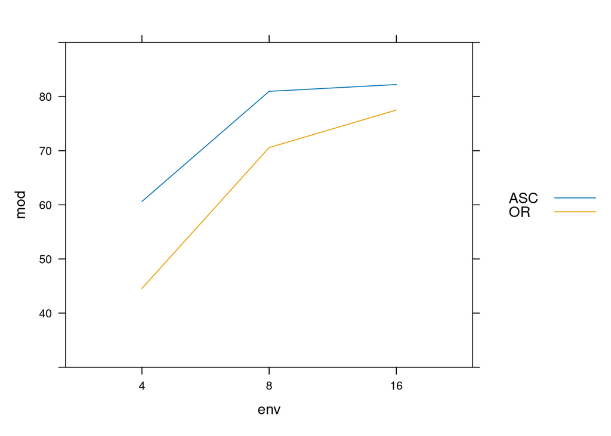

```r
xyplot(mod~env,groups=antiox,type=c("a"),auto.key = T,ylim=c(30,90))
```

**Para 4 años la diferencia entre ASC y OR es mayor que en los otros años, y se nota que cuando se llega a 16 años esa diferencia es muy poca. En todos los casos la media de módulo es mayor para ASC que para OR.**

- Escriba el modelo resultante.

$$\mu_{ijk,X_1,X_2}=\beta_0+\alpha_i+\delta_j+\tau_k+\beta_1
X_1+\beta_2 X_2 +(\alpha \delta)_{ij}$$

- Debido a la presencia de interacción, para hacer intervalos de confianza al comparar las medias de módulo entre los dos antioxidantes, debe considerarse el envejecimiento, pero no es importante considerar el agregado, la temperatura o la frecuencia. Entonces deben hacerse tres intervalos de confianza, uno para cada nivel de envejecimiento. Puesto que se nota que el promedio para ASC es siempre mayor que para OR, es importante ver la media de ASC menos la de OR para cada nivel de envejecimiento. Primero observe los contrastes para antiox y env para estar seguro cuál es el nivel de referencia.

```r
contrasts(antiox)
```

```
##     OR
## ASC  0
## OR   1
```

```r
contrasts(env)
```

```
##    8 16
## 4  0  0
## 8  1  0
## 16 0  1
```

- Se observa que se está usando el **modelo de tratamiento de referencia** (*Esto es por facilidad en terminos de las interpretaciones, en comparación con el modelo de promedio general cuando se tiene covariables en el modelo*) y que la referencia es ASC de antioxidante y el 4 de envejecimiento, es decir que i=1 para ASC, i=2 para OR, j=1 para 4, j=2 para 8, j=3 para 16. Entonces $\alpha_1=\delta_1=0$, además $(\alpha \delta)_{11}=(\alpha \delta)_{12}=(\alpha \delta)_{13}=(\alpha \delta)_{21}=0$. De esta forma usaremos la siguiente notación $\mu_{ij}$ para indicar la media del antioxiante i, el envejecimiento j, el agregado cualquiera, para una temperatura fija y una frecuencia fija. Verifique las siguientes relaciones:

  $\mu_{11}-\mu_{21}= -\alpha_2$

  $\mu_{12}-\mu_{22}= -\alpha_2-(\alpha \delta)_{22}$

  $\mu_{13}-\mu_{23}= -\alpha_2-(\alpha \delta)_{23}$

```r
head(model.matrix(mod5))
```

```
##   (Intercept) antioxOR env8 env16 agregG temp frec antioxOR:env8 antioxOR:env16
## 1           1        0    0     0      0  -10  0.1             0              0
## 2           1        0    0     0      0  -10  0.5             0              0
## 3           1        0    0     0      0  -10  1.0             0              0
## 4           1        0    0     0      0  -10  5.0             0              0
## 5           1        0    0     0      0  -10 10.0             0              0
## 6           1        0    0     0      0  -10 25.0             0              0
```

```r
(promed=tapply(mod,list(antiox,env),mean))
```

```
##            4        8       16
## ASC 60.62234 80.96173 82.21631
## OR  44.55753 70.57362 77.50962
```

```r
promed[1,]-promed[2,]
```

```
##        4        8       16
## 16.06481 10.38811  4.70670
```

```r
mod5$coef
```

```
##    (Intercept)       antioxOR           env8          env16         agregG
##      95.620757     -16.064812      20.339385      21.593972       4.255234
##           temp           frec  antioxOR:env8 antioxOR:env16
##      -2.066375       1.029190       5.676704      11.358112
```

Recuerden que para la estimación de un promedio comparable con alguno observado, se debería estimar el modelo para un lugar de agregado, frecuencia y temperatura particular. **Primero se estima del modelo teórico a nivel general**

$$\mu_{ijk,X_1,X_2}=\beta_0+\alpha_i1(ASC)+\alpha_i2(OR)+\delta_j1(4)+\delta_j2(8)+\delta_j3(16)+\tau_k1(Barran)+\tau_k2(Guap)+\beta_1
X_1(Temp)+\beta_2 X_2(Frec) +(\alpha \delta)_{ij}$$

$\mu_{11}-\mu_{21}= -\alpha_2$

$$\mu_{11k,X_1,X_2}=\beta_0+\alpha_i1(ASC)+\delta_j1(4)+\tau_k(constante)+\beta_1
X_1(Temp)+\beta_2 X_2(Frec) +(\alpha \delta)_11$$

$$\mu_{21k,X_1,X_2}=\beta_0+\alpha_i2(OR)+\delta_j1(4)+\tau_k(constante)+\beta_1
X_1(Temp)+\beta_2 X_2(Frec) +(\alpha \delta)_21$$

$$\mu_{11}-\mu_{21}=\alpha_i1(ASC)+(\alpha
\delta)_11-\alpha_i2(OR)-(\alpha \delta)_21$$

**Al realizar la evaluación de este modelo particular, el $\alpha_i1$ es igual a 0.**

$\mu_{12}-\mu_{22}= -\alpha_2-(\alpha \delta)_{22}$

$$\mu_{12k,X_1,X_2}=\beta_0+\alpha_i1(ASC)+\delta_j2(8)+\tau_k(constante)+\beta_1
X_1(Temp)+\beta_2 X_2(Frec) +(\alpha \delta)_12$$

$$\mu_{22k,X_1,X_2}=\beta_0+\alpha_i2(OR)+\delta_j2(8)+\tau_k(constante)+\beta_1
X_1(Temp)+\beta_2 X_2(Frec) +(\alpha \delta)_22$$

$$\mu_{12}-\mu_{22}=\alpha_i1(ASC)+(\alpha
\delta)_12-\alpha_i2(OR)-(\alpha \delta)_22$$

- Observe los coeficientes del modelo y escriba los coeficientes para los tres contrastes escritos anteriormente.

```r
mod5$coef
```

```
##    (Intercept)       antioxOR           env8          env16         agregG
##      95.620757     -16.064812      20.339385      21.593972       4.255234
##           temp           frec  antioxOR:env8 antioxOR:env16
##      -2.066375       1.029190       5.676704      11.358112
```

```r
c1=c(0,-1,0,0,0,0,0,0,0)
c2=c(0,-1,0,0,0,0,0,-1,0)
c3=c(0,-1,0,0,0,0,0,0,-1)
```

- Encuentre las estimaciones de los contrastes.

```r
beta=mod5$coef
cont=cbind(c1,c2,c3)
L=t(cont)%*%beta
row.names(L)=c("ASC-OR,4años","ASC-OR,8años","ASC-OR,16años")
L
```

```
##                   [,1]
## ASC-OR,4años  16.06481
## ASC-OR,8años  10.38811
## ASC-OR,16años  4.70670
```

- Verifique la hipótesis para cada contraste usando solo una cola, es decir, poniendo la alternativa $H_1:L>0$. Puesto que los contrastes no son ortogonales debe ajustar el $\alpha$.

```r
ee=sqrt(diag(t(cont)%*%vcov(mod5)%*%cont))
t=L/ee
t
```

```
##                   [,1]
## ASC-OR,4años  5.561379
## ASC-OR,8años  3.596196
## ASC-OR,16años 1.629384
```

```r
anova(mod5)
```

```
## Analysis of Variance Table
##
## Response: mod
##             Df Sum Sq Mean Sq   F value    Pr(>F)
## antiox       1   9709    9709   38.7862 1.352e-09 ***
## env          2  51912   25956  103.6882 < 2.2e-16 ***
## agreg        1   1630    1630    6.5100   0.01115 *
## temp         1 812721  812721 3246.6371 < 2.2e-16 ***
## frec         1  29415   29415  117.5059 < 2.2e-16 ***
## antiox:env   2   1935     968    3.8651   0.02186 *
## Residuals  351  87865     250
## ---
## Signif. codes:  0 '***' 0.001 '**' 0.01 '*' 0.05 '.' 0.1 ' ' 1
```

```r
p=pt(t,351,lower.tail=F)
round(p,4)
```

```
##                 [,1]
## ASC-OR,4años  0.0000
## ASC-OR,8años  0.0002
## ASC-OR,16años 0.0521
```

```r
alfa=0.05/3
alfa
```

```
## [1] 0.01666667
```

**Se rechaza la hipótesis sólo para los dos primeros contrastes, lo cual indica que efectivamente sólo para 4 y 8 años se obtiene un módulo promedio mayor para ASC que para OR, en cambio para 16 años no hay evidencia de que esto sea así.**

- Construya los intervalos de confianza inferiores en los casos de 4 y 8 años e interprete el resultado según la relevancia que estableció el investigador.

```r
t=qt(1-0.05/2,351)
lim=L[1:2]-t*ee[1:2]
names(lim)=row.names(L)[1:2]
round(lim,2)
```

```
## ASC-OR,4años ASC-OR,8años
##        10.38         4.71
```

```r
#lim_s=L[1:2]+t*ee[1:2]
#names(lim_s)=row.names(L)[1:2]
#round(lim_s,2)
```

**Puesto que la diferencia mínima que definió el investigador como relevante entre dos promedios era 10 MegaPascales, se tiene que para 4 años sí se ha demostrado que el antioxidante ASC es mayor que el OR, sin embargo, para 8 años, aunque esta diferencia es estadísticamente significativa, apenas se ha demostrado que es mayor que 4.71 MegaPascales por lo que no es un resultado definitivo y claro en cuanto a que haya una diferencia relevante. Se concluye que el antioxidante Orujo produce un módulo promedio menor que el Ácido Ascórbico cuando se tiene un envejecimiento de 4 años pero que conforme pasa el tiempo esa diferencia se va haciendo más pequeña a tal pundo que puede no ser muy relevante.**